# hw3-pog4

Pooja Ghatge

February 23, 2018

#### Q1

```r
# hw3sample.R - sample code for hw3
#
# @author: Yu-Ru Lin
# @date: 2015-02-05
library(car)
library(caTools)
library(textir)
```

```r
library(data.table)
library(MASS) # for the example dataset
library(plyr) # for recoding data
library(ROCR) # for plotting roc
library(e1071) # for NB and SVM
library(rpart) # for decision tree
library(ada) # for adaboost
library(class) #knn
set.seed(12345) # set the seed so you can get exactly the same results whenever you run the code

do.classification <- function(train.set, test.set,
                              cl.name, verbose=F) {
  ## note: to plot ROC later, we want the raw probabilities,
  ## not binary decisions
  switch(cl.name,
         knn = { # here we test k=3; you should evaluate different k's
           prob = knn(train.set[,-1], test.set[,-1], cl=train.set[,1], k = 3, prob=T)
           prob = attr(prob,"prob")
           #print(cbind(prob,as.character(test.set$y)))
           prob
         },
         lr = { # logistic regression
           model = glm(y~., family=binomial, data=train.set)
           if (verbose) {
             print(summary(model))
           }
           prob = predict(model, newdata=test.set, type="response")
           #print(cbind(prob,as.character(test.set$y)))
           prob
         },
         nb = {
           model = naiveBayes(y~., data=train.set)
           prob = predict(model, newdata=test.set, type="raw")
           #print(cbind(prob,as.character(test.set$y)))
           prob = prob[,2]/rowSums(prob) # renormalize the prob.
           prob
         },
         dtree = {
           model = rpart(y~., data=train.set, method="class")
           if (verbose) {
             print(summary(model)) # detailed summary of splits
             printcp(model) # print the cross-validation results
             plotcp(model) # visualize the cross-validation results
             ## plot the tree
             plot(model, uniform=TRUE, main="Classification Tree")
             text(model, use.n=TRUE, all=TRUE, cex=.8)
           }
           prob = predict(model, newdata=test.set, type="prob")

           if (0) { # here we use the default tree,
             ## you should evaluate different size of tree
             ## prune the tree
             pfit<- prune(model, cp=model$cptable[which.min(model$cptable[,"xerror"]),"CP"])
             prob = predict(pfit, newdata=test.set, type="prob")
             ## plot the pruned tree
             plot(pfit, uniform=TRUE,main="Pruned Classification Tree")
             text(pfit, use.n=TRUE, all=TRUE, cex=.8)
           }
           print(dim(prob))
           #print(cbind(prob,as.character(test.set$y)))
           prob = prob[,2]/rowSums(prob) # renormalize the prob.
           prob
         },
         svm = {
           model = svm(y~., data=train.set,type="C-classification",kernel="linear", probability=TRUE)
           if (0) { # fine-tune the model with different kernel and parameters
             ## evaluate the range of gamma parameter between 0.000001 and 0.1
             ## and cost parameter from 0.1 until 10
             tuned <- tune.svm(y~., data = train.set,
                               kernel="radial", probability=TRUE,
                               gamma = 10^(-6:-1), cost = 10^(-1:1))
             #print(summary(tuned))
             gamma = tuned[['best.parameters']]$gamma
             cost = tuned[['best.parameters']]$cost
             model = svm(y~., data = train.set, probability=TRUE,
                         kernel="radial", gamma=gamma, cost=cost)
           }
           prob = predict(model, newdata=test.set,probability=TRUE)

           prob=attr(prob,"probabilities")

           prob = prob[,which(colnames(prob)==1)]/rowSums(prob)
           prob
         },
         ada = {
           model = ada(y~., data = train.set)
           prob = predict(model, newdata=test.set, type='probs')
           #print(cbind(prob,as.character(test.set$y)))
           prob = prob[,2]/rowSums(prob)
           prob
         }
  )
}
#svm_result = my.classifier(dataset, cl.name='svm',do.cv=T)
pre.test <- function(dataset, cl.name, r=0.6, prob.cutoff=0.5) {
  ## Let's use 60% random sample as training and remaining as testing
  ## by default use 0.5 as cut-off
  n.obs <- nrow(dataset) # no. of observations in dataset
  n.train = floor(n.obs*r)
  train.idx = sample(1:n.obs,n.train)
  train.idx
  train.set = dataset[train.idx,]
  test.set = dataset[-train.idx,]
  cat('pre-test',cl.name,':',
      '#training:',nrow(train.set),
      '#testing',nrow(test.set),'\n')
  prob = do.classification(train.set, test.set, cl.name)
  # prob is an array of probabilities for cases being positive

  ## get confusion matrix
  predicted = as.numeric(prob > prob.cutoff)
  actual = test.set$y
  confusion.matrix = table(actual,factor(predicted,levels=c(0,1)))
  error = (confusion.matrix[1,2]+confusion.matrix[2,1]) / nrow(test.set)
  cat('error rate:',error,'\n')
  # you may compute other measures based on confusion.matrix
  # @see handout03 p.32-36

  ## plot ROC
  result = data.frame(prob,actual)
  pred = prediction(result$prob,result$actual)
  perf = performance(pred, "tpr","fpr")
}
k.fold.cv <- function(dataset, cl.name, k.fold=10, prob.cutoff=0.5) {
  ## default: 10-fold CV, cut-off 0.5
  n.obs <- nrow(dataset) # no. of observations
  s = sample(n.obs)
  errors = dim(k.fold)
  probs = NULL
  actuals = NULL
  for (k in 1:k.fold) {
    test.idx = which(s %% k.fold == (k-1) ) # use modular operator
    train.set = dataset[-test.idx,]
    test.set = dataset[test.idx,]
    cat(k.fold,'-fold CV run',k,cl.name,':',
        '#training:',nrow(train.set),
        '#testing',nrow(test.set),'\n')
    prob = do.classification(train.set, test.set, cl.name)
    predicted = as.numeric(prob > prob.cutoff)
    actual = test.set$y
    confusion.matrix = table(actual,factor(predicted,levels=c(0,1)))
    confusion.matrix
    error = (confusion.matrix[1,2]+confusion.matrix[2,1]) / nrow(test.set)
    errors[k] = error
    cat('\t\terror=',error,'\n')
    probs = c(probs,prob)
    actuals = c(actuals,actual)
    ## you may compute other measures and store them in arrays
  }
  avg.error = mean(errors)
  cat(k.fold,'-fold CV results:','avg error=',avg.error,'\n')

  ## plot ROC
  result = data.frame(probs,actuals)
  pred = prediction(result$probs,result$actuals)
  perf = performance(pred, "tpr","fpr")


  ## get other measures by using 'performance'
  get.measure <- function(pred, measure.name='auc') {
    perf = performance(pred,measure.name)
    m <- unlist(slot(perf, "y.values"))
    #     print(slot(perf, "x.values"))
    #     print(slot(perf, "y.values"))
    m
  }
  err = mean(get.measure(pred, 'err'))
  precision = mean(get.measure(pred, 'prec'),na.rm=T)
  recall = mean(get.measure(pred, 'rec'),na.rm=T)
  fscore = mean(get.measure(pred, 'f'),na.rm=T)
  cat('error=',err,'precision=',precision,'recall=',recall,'f-score',fscore,'\n')
  auc = get.measure(pred, 'auc')
  cat('auc=',auc,'\n')
  vectorx=c(err,precision,recall,fscore,auc)
  return(vectorx)
}
my.classifier <- function(dataset, cl.name='knn', do.cv=F) {
  n.obs <- nrow(dataset) # no. of observations in dataset
  n.cols <- ncol(dataset) # no. of predictors
  cat('my dataset:',
      n.obs,'observations',
      n.cols-1,'predictors','\n')

  pre.test(dataset, cl.name)
  if (do.cv) vectorx=k.fold.cv(dataset, cl.name)
  return(vectorx)
}

load.data.example <- function() {

  dataset= read.csv("pokemon.csv", header=T)
  head(dataset[3:5,])
  dataset=dataset[,-1]
  dataset=dataset[,-1]

  dataset$Total=recode(dataset$Total,"'>500'=1;else=0")
  dataset$Total=as.numeric(levels(dataset$Total)[dataset$Total])
  dataset$Generation=as.factor(dataset$Generation)

  dataset_mat= model.matrix(Total~.,data=dataset)[,-1]
  dataset=cbind(dataset_mat,dataset$Total)
  dataset=data.frame(dataset)

  dataset[1:3,]
  dataset <- subset(dataset, select = -c(Type.2NO) )
  dataset[,c(35:40)]=scale(dataset[,c(35:40)])
  dataset=rename(dataset,c('V48'='y'))
  #y = mapvalues(cats$Sex, from=c('F','M'), to=c(0,1))
  return(dataset)
}


### main ###
dataset = load.data.example()
knn_result = my.classifier(dataset, cl.name='knn',do.cv=T)
```

```
## my dataset: 800 observations 46 predictors
## pre-test knn : #training: 480 #testing 320
## error rate: 0.753125
## 10 -fold CV run 1 knn : #training: 720 #testing 80
##      error= 0.725
## 10 -fold CV run 2 knn : #training: 720 #testing 80
##      error= 0.7625
## 10 -fold CV run 3 knn : #training: 720 #testing 80
##      error= 0.7
## 10 -fold CV run 4 knn : #training: 720 #testing 80
##      error= 0.8
## 10 -fold CV run 5 knn : #training: 720 #testing 80
##      error= 0.75
## 10 -fold CV run 6 knn : #training: 720 #testing 80
##      error= 0.675
## 10 -fold CV run 7 knn : #training: 720 #testing 80
##      error= 0.6875
## 10 -fold CV run 8 knn : #training: 720 #testing 80
##      error= 0.7375
## 10 -fold CV run 9 knn : #training: 720 #testing 80
##      error= 0.675
## 10 -fold CV run 10 knn : #training: 720 #testing 80
##      error= 0.7
## 10 -fold CV results: avg error= 0.72125
## error= 0.6220833 precision= 0.27543 recall= 0.750744 f-score 0.4214563
## auc= 0.4845571
```

```r
nb_result = my.classifier(dataset, cl.name='nb',do.cv=T)
```

```
## my dataset: 800 observations 46 predictors
## pre-test nb : #training: 480 #testing 320
## error rate: 0.209375
## 10 -fold CV run 1 nb : #training: 720 #testing 80
##      error= 0.1875
## 10 -fold CV run 2 nb : #training: 720 #testing 80
##      error= 0.1375
## 10 -fold CV run 3 nb : #training: 720 #testing 80
##      error= 0.225
## 10 -fold CV run 4 nb : #training: 720 #testing 80
##      error= 0.125
## 10 -fold CV run 5 nb : #training: 720 #testing 80
##      error= 0.25
## 10 -fold CV run 6 nb : #training: 720 #testing 80
##      error= 0.25
## 10 -fold CV run 7 nb : #training: 720 #testing 80
##      error= 0.2125
## 10 -fold CV run 8 nb : #training: 720 #testing 80
##      error= 0.175
## 10 -fold CV run 9 nb : #training: 720 #testing 80
##      error= 0.15
## 10 -fold CV run 10 nb : #training: 720 #testing 80
##      error= 0.1875
## 10 -fold CV results: avg error= 0.19
## error= 0.3757539 precision= 0.4967289 recall= 0.7552633 f-score 0.5360456
## auc= 0.8185454
```

```r
lr_result = my.classifier(dataset, cl.name='lr',do.cv=T)
```

```
## my dataset: 800 observations 46 predictors
## pre-test lr : #training: 480 #testing 320
## error rate: 0.053125
## 10 -fold CV run 1 lr : #training: 720 #testing 80
##      error= 0.05
## 10 -fold CV run 2 lr : #training: 720 #testing 80
##      error= 0.0375
## 10 -fold CV run 3 lr : #training: 720 #testing 80
##      error= 0.0125
## 10 -fold CV run 4 lr : #training: 720 #testing 80
##      error= 0
## 10 -fold CV run 5 lr : #training: 720 #testing 80
##      error= 0.05
## 10 -fold CV run 6 lr : #training: 720 #testing 80
##      error= 0.0125
## 10 -fold CV run 7 lr : #training: 720 #testing 80
##      error= 0.0875
## 10 -fold CV run 8 lr : #training: 720 #testing 80
##      error= 0.0375
## 10 -fold CV run 9 lr : #training: 720 #testing 80
##      error= 0.0125
## 10 -fold CV run 10 lr : #training: 720 #testing 80
##      error= 0.0125
## 10 -fold CV results: avg error= 0.03125
## error= 0.05291667 precision= 0.9133556 recall= 0.9293155 f-score 0.9237791
## auc= 0.9878123
```

```r
dtree_result = my.classifier(dataset, cl.name='dtree',do.cv=T)
```

```
## my dataset: 800 observations 46 predictors
## pre-test dtree : #training: 480 #testing 320
## [1] 320   2
## error rate: 0.121875
## 10 -fold CV run 1 dtree : #training: 720 #testing 80
## [1] 80  2
##      error= 0.1125
## 10 -fold CV run 2 dtree : #training: 720 #testing 80
## [1] 80  2
##      error= 0.1375
## 10 -fold CV run 3 dtree : #training: 720 #testing 80
## [1] 80  2
##      error= 0.15
## 10 -fold CV run 4 dtree : #training: 720 #testing 80
## [1] 80  2
##      error= 0.175
## 10 -fold CV run 5 dtree : #training: 720 #testing 80
## [1] 80  2
##      error= 0.1375
## 10 -fold CV run 6 dtree : #training: 720 #testing 80
## [1] 80  2
##      error= 0.175
## 10 -fold CV run 7 dtree : #training: 720 #testing 80
## [1] 80  2
##      error= 0.15
## 10 -fold CV run 8 dtree : #training: 720 #testing 80
## [1] 80  2
##      error= 0.225
## 10 -fold CV run 9 dtree : #training: 720 #testing 80
## [1] 80  2
##      error= 0.1875
## 10 -fold CV run 10 dtree : #training: 720 #testing 80
## [1] 80  2
##      error= 0.1375
## 10 -fold CV results: avg error= 0.15875
## error= 0.2299425 precision= 0.6818059 recall= 0.646757 f-score 0.6120441
## auc= 0.8649747
```

```r
svm_result = my.classifier(dataset, cl.name='svm',do.cv=T)
```

```
## my dataset: 800 observations 46 predictors
## pre-test svm : #training: 480 #testing 320
## error rate: 0.0625
## 10 -fold CV run 1 svm : #training: 720 #testing 80
##      error= 0.05
## 10 -fold CV run 2 svm : #training: 720 #testing 80
##      error= 0.025
## 10 -fold CV run 3 svm : #training: 720 #testing 80
##      error= 0.025
## 10 -fold CV run 4 svm : #training: 720 #testing 80
##      error= 0.025
## 10 -fold CV run 5 svm : #training: 720 #testing 80
##      error= 0.0125
## 10 -fold CV run 6 svm : #training: 720 #testing 80
##      error= 0.025
## 10 -fold CV run 7 svm : #training: 720 #testing 80
##      error= 0.0375
## 10 -fold CV run 8 svm : #training: 720 #testing 80
##      error= 0.0125
## 10 -fold CV run 9 svm : #training: 720 #testing 80
##      error= 0.0125
## 10 -fold CV run 10 svm : #training: 720 #testing 80
##      error= 0.025
## 10 -fold CV results: avg error= 0.025
## error= 0.1633878 precision= 0.772074 recall= 0.8332179 f-score 0.7377652
## auc= 0.9975508
```

```r
ada_result = my.classifier(dataset, cl.name='ada',do.cv=T)
```

```
## my dataset: 800 observations 46 predictors
## pre-test ada : #training: 480 #testing 320
## error rate: 0.03125
## 10 -fold CV run 1 ada : #training: 720 #testing 80
##      error= 0.025
## 10 -fold CV run 2 ada : #training: 720 #testing 80
##      error= 0.1125
## 10 -fold CV run 3 ada : #training: 720 #testing 80
##      error= 0.05
## 10 -fold CV run 4 ada : #training: 720 #testing 80
##      error= 0.0375
## 10 -fold CV run 5 ada : #training: 720 #testing 80
##      error= 0.0875
## 10 -fold CV run 6 ada : #training: 720 #testing 80
##      error= 0.0625
## 10 -fold CV run 7 ada : #training: 720 #testing 80
##      error= 0.1
## 10 -fold CV run 8 ada : #training: 720 #testing 80
##      error= 0.025
## 10 -fold CV run 9 ada : #training: 720 #testing 80
##      error= 0.075
## 10 -fold CV run 10 ada : #training: 720 #testing 80
##      error= 0.0625
## 10 -fold CV results: avg error= 0.06375
## error= 0.1843175 precision= 0.7442619 recall= 0.8125357 f-score 0.7082132
## auc= 0.9802905
```

```r
# cl.name can take 'lr','knn','nb','dtree','svm','ada'
measures=c('err','precision','recall','fscore','AUC')
Table=rbind(measures,knn_result,nb_result,lr_result,dtree_result,ada_result,svm_result)
Table
```

```
##              [,1]                 [,2]                [,3]
## measures     "err"                "precision"         "recall"
## knn_result   "0.622083333333333"  "0.27543001892489"  "0.750744047619048"
## nb_result    "0.375753891050584"  "0.496728920842435" "0.755263340744858"
## lr_result    "0.0529166666666667" "0.913355593671996" "0.929315476190476"
## dtree_result "0.229942528735632"  "0.681805867254261" "0.64675697865353"
## ada_result   "0.1843175"          "0.744261855386185" "0.812535714285714"
## svm_result   "0.163387755102041"  "0.772074023552161" "0.833217930029155"
##              [,4]                [,5]
## measures     "fscore"            "AUC"
## knn_result   "0.421456268084625" "0.484557136656746"
## nb_result    "0.536045618017589" "0.818545386904764"
## lr_result    "0.923779147081733" "0.987812344990079"
## dtree_result "0.612044103795437" "0.864974733382937"
## ada_result   "0.708213247481231" "0.98029048859127"
## svm_result   "0.737765151331426" "0.997550843253968"
```

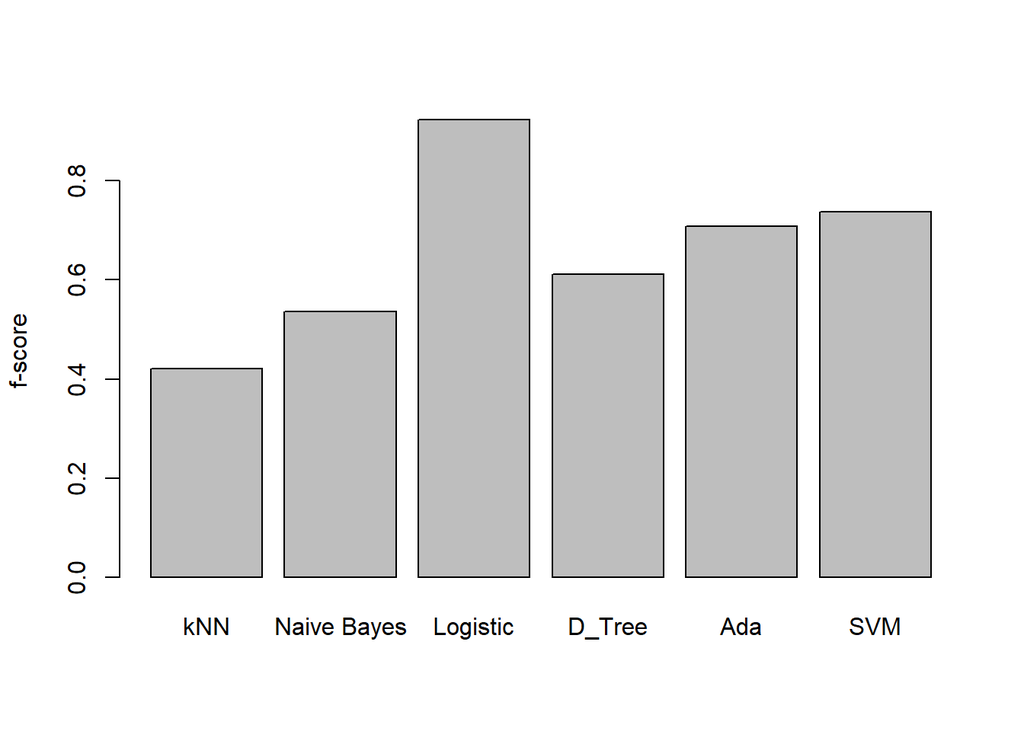

```r
fscore_vector=as.numeric(Table[2:7,4])
AUC_vector=as.numeric(Table[2:7,5])
barplot(fscore_vector,names.arg=c('kNN','Naive Bayes','Logistic','D_Tree','Ada','SVM'), ylab='f-score')
```

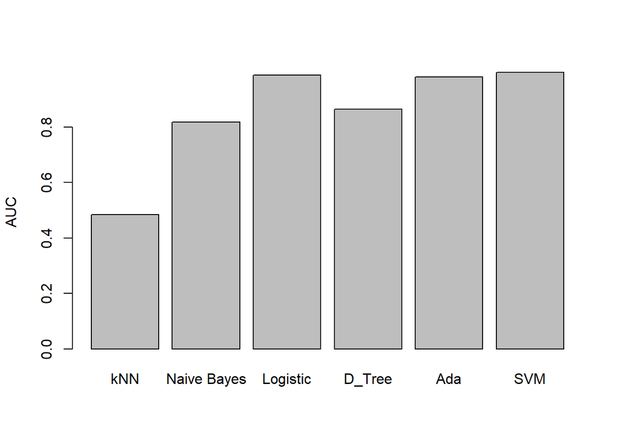

```r
barplot(AUC_vector,names.arg=c('kNN','Naive Bayes','Logistic','D_Tree','Ada','SVM'), ylab='AUC')
```

#### Q2

```r
do.classification <- function(train.set, test.set,
                              cl.name, verbose=F) {
  ## note: to plot ROC later, we want the raw probabilities,
  ## not binary decisions
  switch(cl.name,
         knn = { # here we test k=3; you should evaluate different k's
           prob = knn(train.set[,-1], test.set[,-1], cl=train.set[,1], k = 2, prob=T)
           prob = attr(prob,"prob")
           #print(cbind(prob,as.character(test.set$y)))
           prob
         },

         dtree = {
           model = rpart(y~., data=train.set, method="class")
           if (verbose) {
             print(summary(model)) # detailed summary of splits
             printcp(model) # print the cross-validation results
             plotcp(model) # visualize the cross-validation results
             ## plot the tree
             plot(model, uniform=TRUE, main="Classification Tree")
             text(model, use.n=TRUE, all=TRUE, cex=.8)
           }

           if (1) { # here we use the default tree,
             ## you should evaluate different size of tree
             ## prune the tree
             pfit<- prune(model, cp=model$cptable[which.min(model$cptable[,"xerror"]),"CP"])
             prob = predict(pfit, newdata=test.set, type="prob")
             ## plot the pruned tree
             plot(pfit, uniform=TRUE,main="Pruned Classification Tree")
             text(pfit, use.n=TRUE, all=TRUE, cex=.8)
           }
          prob = predict(model, newdata=test.set, type="prob")
           print(dim(prob))
           #print(cbind(prob,as.character(test.set$y)))
           prob = prob[,2]/rowSums(prob) # renormalize the prob.
           prob
         },
         svm = {

           if (1) { # fine-tune the model with different kernel and parameters
             ## evaluate the range of gamma parameter between 0.000001 and 0.1
             ## and cost parameter from 0.1 until 10
             tuned <- tune.svm(y~., data = train.set,
                               kernel="radial", probability=TRUE,
                               gamma = 10^(-6:-1), cost = 10^(-1:1))
             #print(summary(tuned))
             gamma = tuned[['best.parameters']]$gamma
             cost = tuned[['best.parameters']]$cost
             model = svm(y~., data = train.set, probability=TRUE,
                         type="C-classification",
                         kernel="radial", gamma=gamma, cost=cost)
           }
           prob = predict(model, newdata=test.set,probability=TRUE)

           prob=attr(prob,"probabilities")

           prob = prob[,which(colnames(prob)==1)]/rowSums(prob)
           prob
         }
  )
}

dataset = load.data.example()
knn2_result = my.classifier(dataset, cl.name='knn',do.cv=T)
```

```
## my dataset: 800 observations 46 predictors
## pre-test knn : #training: 480 #testing 320
## error rate: 0.68125
## 10 -fold CV run 1 knn : #training: 720 #testing 80
##      error= 0.7125
## 10 -fold CV run 2 knn : #training: 720 #testing 80
##      error= 0.65
## 10 -fold CV run 3 knn : #training: 720 #testing 80
##      error= 0.775
## 10 -fold CV run 4 knn : #training: 720 #testing 80
##      error= 0.7125
## 10 -fold CV run 5 knn : #training: 720 #testing 80
##      error= 0.7125
## 10 -fold CV run 6 knn : #training: 720 #testing 80
##      error= 0.625
## 10 -fold CV run 7 knn : #training: 720 #testing 80
##      error= 0.65
## 10 -fold CV run 8 knn : #training: 720 #testing 80
##      error= 0.675
## 10 -fold CV run 9 knn : #training: 720 #testing 80
##      error= 0.8
## 10 -fold CV run 10 knn : #training: 720 #testing 80
##      error= 0.7
## 10 -fold CV results: avg error= 0.70125
## error= 0.61925 precision= 0.2742373 recall= 0.7366071 f-score 0.4225049
## auc= 0.4834488
```

```r
dtree_pruned_result = my.classifier(dataset, cl.name='dtree',do.cv=T)
```

```
## my dataset: 800 observations 46 predictors
## pre-test dtree : #training: 480 #testing 320
```

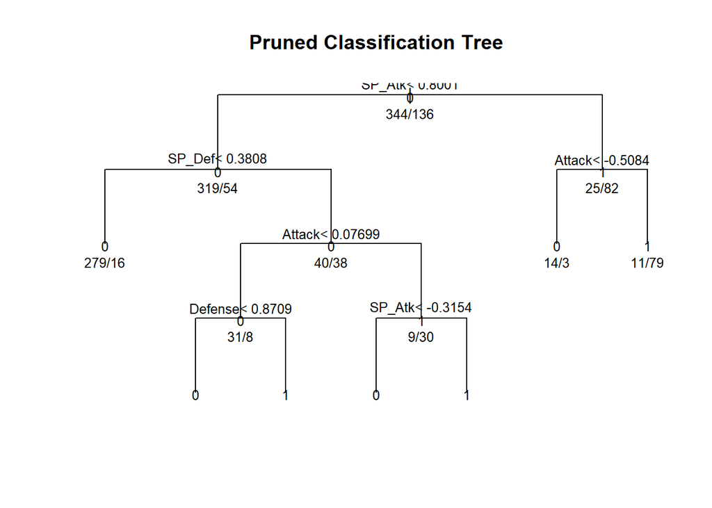

```
## [1] 320   2
## error rate: 0.14375
## 10 -fold CV run 1 dtree : #training: 720 #testing 80
```

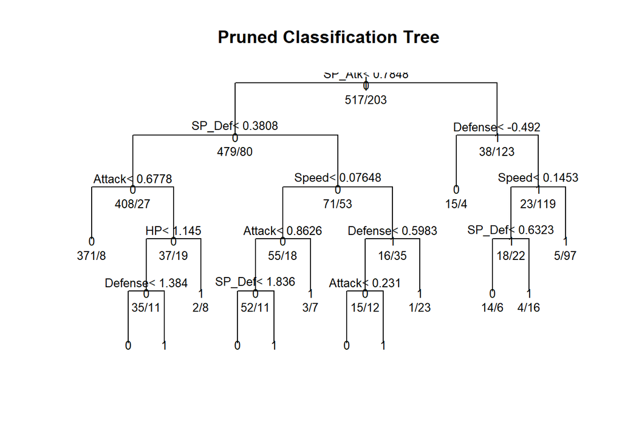

```
## [1] 80  2
##      error= 0.125
## 10 -fold CV run 2 dtree : #training: 720 #testing 80
```

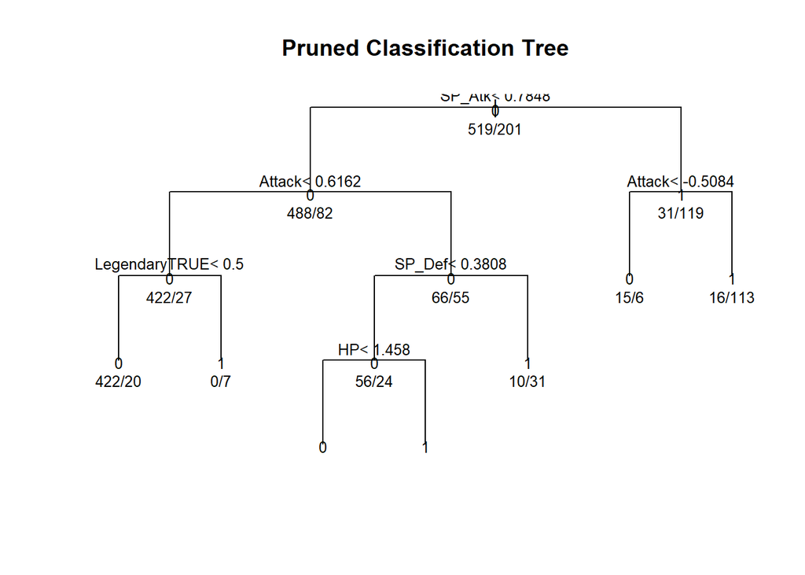

```
## [1] 80  2
##      error= 0.15
## 10 -fold CV run 3 dtree : #training: 720 #testing 80
```

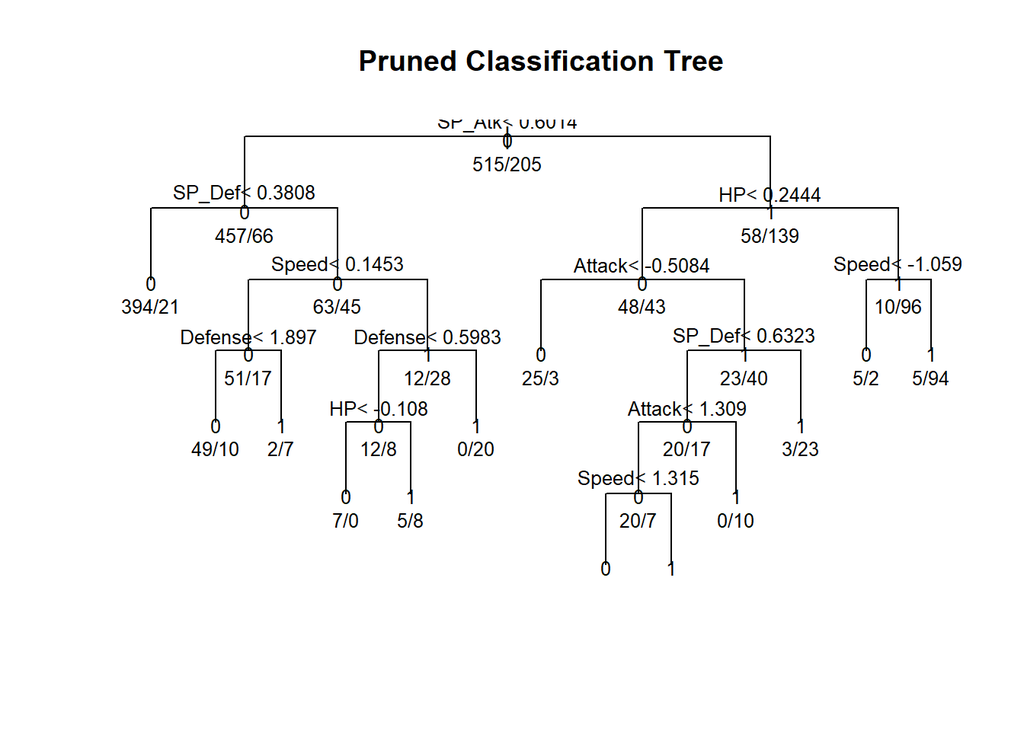

```
## [1] 80  2
##      error= 0.125
## 10 -fold CV run 4 dtree : #training: 720 #testing 80
```

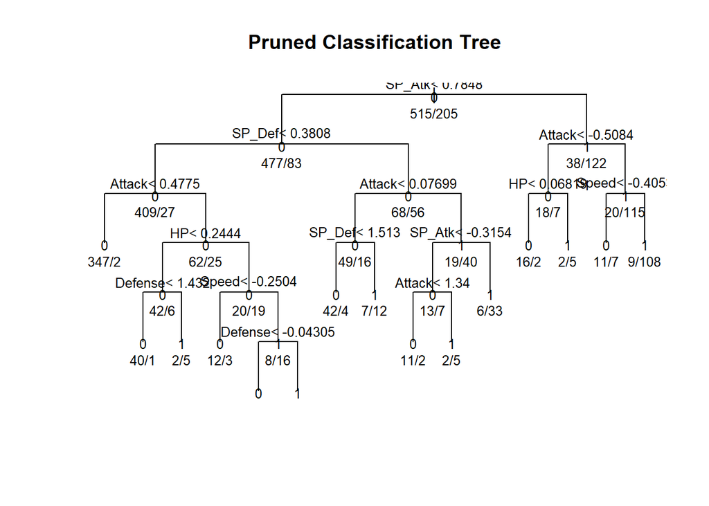

```
## [1] 80  2
##      error= 0.175
## 10 -fold CV run 5 dtree : #training: 720 #testing 80
```

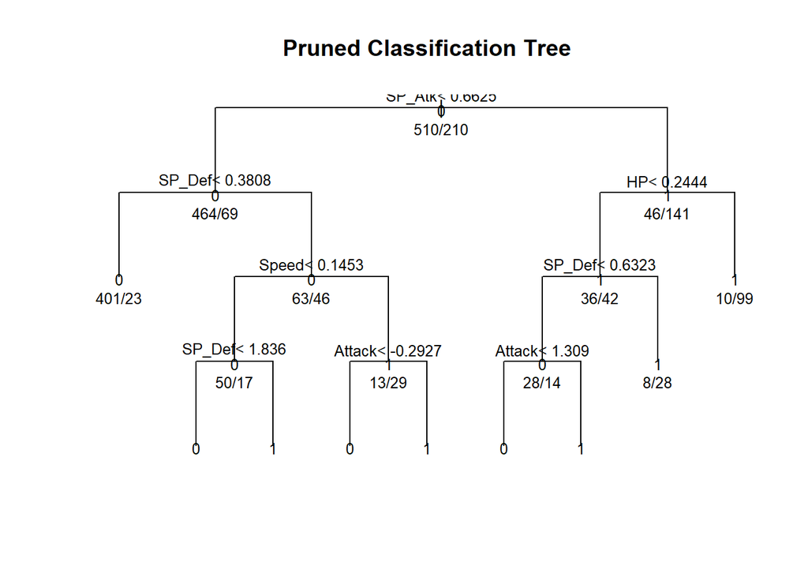

```
## [1] 80  2
##      error= 0.15
## 10 -fold CV run 6 dtree : #training: 720 #testing 80
```

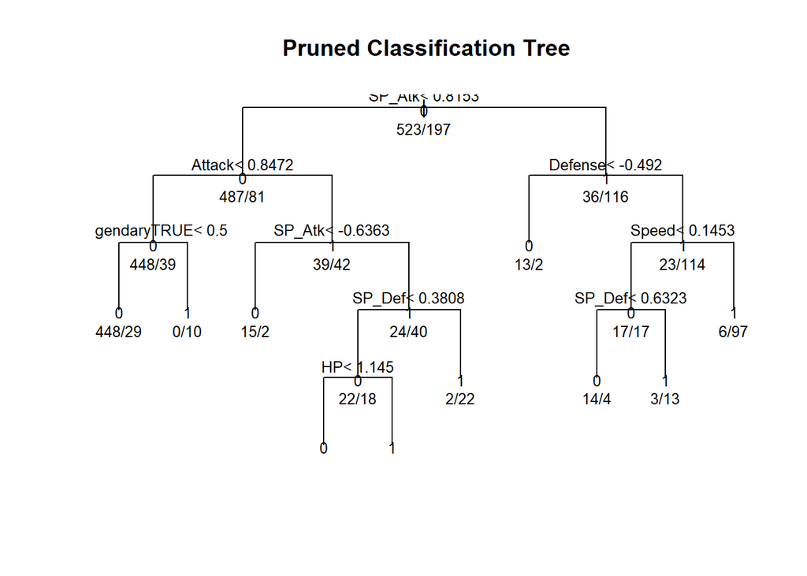

```
## [1] 80  2
##      error= 0.1625
## 10 -fold CV run 7 dtree : #training: 720 #testing 80
```

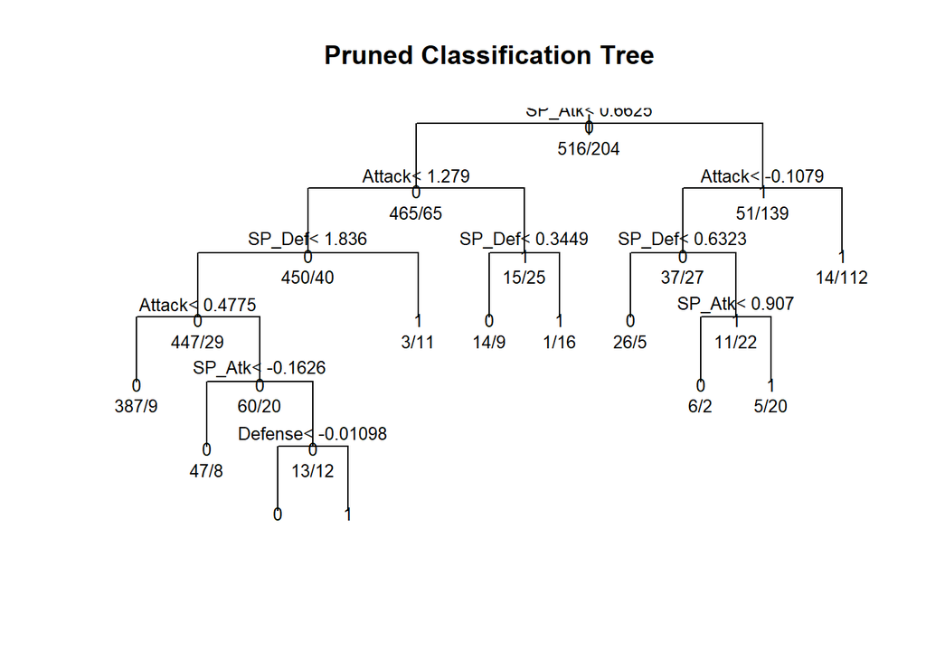

```
## [1] 80  2
##      error= 0.1625
## 10 -fold CV run 8 dtree : #training: 720 #testing 80
```

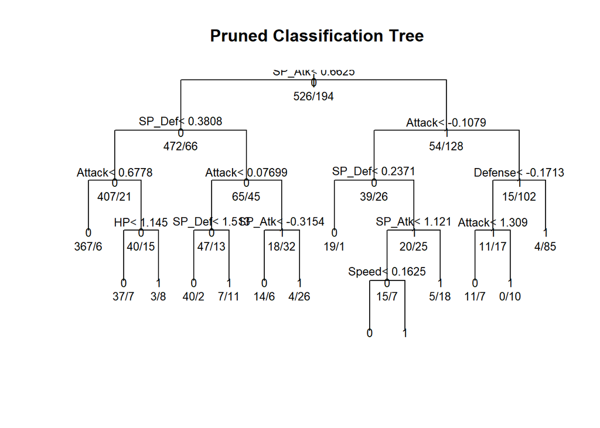

```
## [1] 80  2
##      error= 0.125
## 10 -fold CV run 9 dtree : #training: 720 #testing 80
```

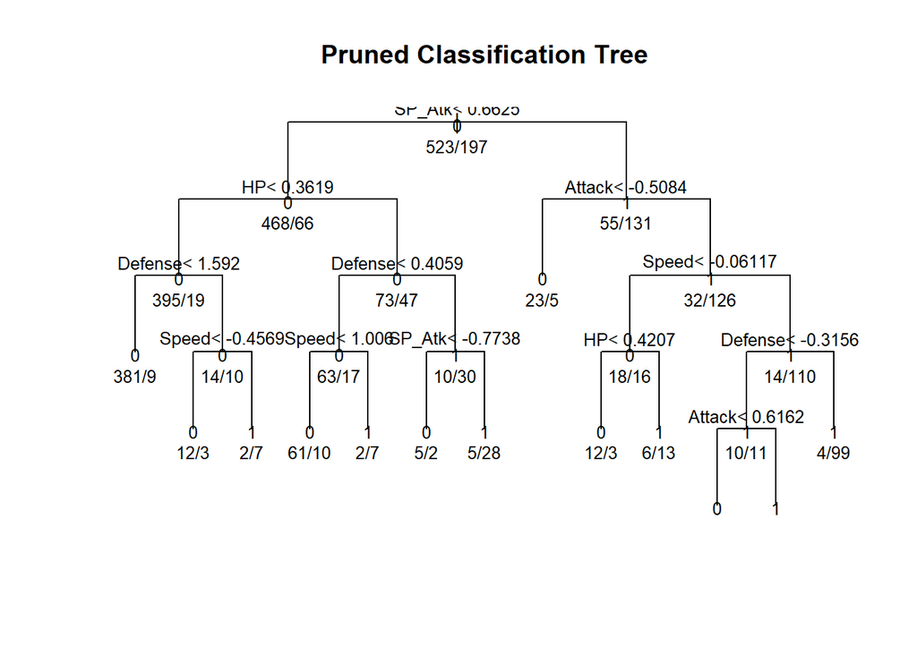

```
## [1] 80  2
##      error= 0.1625
## 10 -fold CV run 10 dtree : #training: 720 #testing 80
```

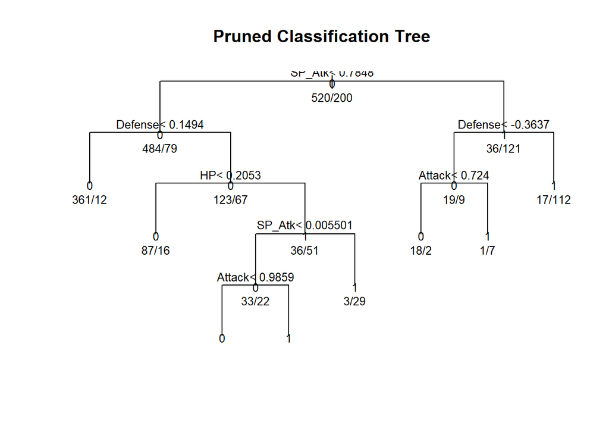

```
## [1] 80  2
##      error= 0.1875
## 10 -fold CV results: avg error= 0.1525
## error= 0.2194306 precision= 0.7062646 recall= 0.6699901 f-score 0.6342409
## auc= 0.8897918
```

```r
svm_radial_result = my.classifier(dataset, cl.name='svm',do.cv=T)
```

```
## my dataset: 800 observations 46 predictors
## pre-test svm : #training: 480 #testing 320
## error rate: 0.1
## 10 -fold CV run 1 svm : #training: 720 #testing 80
##      error= 0.0125
## 10 -fold CV run 2 svm : #training: 720 #testing 80
##      error= 0.05
## 10 -fold CV run 3 svm : #training: 720 #testing 80
##      error= 0.075
## 10 -fold CV run 4 svm : #training: 720 #testing 80
##      error= 0.05
## 10 -fold CV run 5 svm : #training: 720 #testing 80
##      error= 0.075
## 10 -fold CV run 6 svm : #training: 720 #testing 80
##      error= 0.0375
## 10 -fold CV run 7 svm : #training: 720 #testing 80
##      error= 0.0625
## 10 -fold CV run 8 svm : #training: 720 #testing 80
##      error= 0.0375
## 10 -fold CV run 9 svm : #training: 720 #testing 80
##      error= 0.05
## 10 -fold CV run 10 svm : #training: 720 #testing 80
##      error= 0.025
## 10 -fold CV results: avg error= 0.0475
## error= 0.2385448 precision= 0.6933423 recall= 0.8233825 f-score 0.6604407
## auc= 0.9899592
```

```r
# cl.name can take 'lr','knn','nb','dtree','svm','ada'
measures=c('err','precision','recall','fscore','AUC')
Table=rbind(measures,knn_result,knn2_result,dtree_result,dtree_pruned_result,svm_result,svm_radial_result)
Table
```

```
##                     [,1]                [,2]
## measures            "err"               "precision"
## knn_result          "0.622083333333333" "0.27543001892489"
## knn2_result         "0.61925"           "0.274237328535322"
## dtree_result        "0.229942528735632" "0.681805867254261"
## dtree_pruned_result "0.219430555555556" "0.706264606187534"
## svm_result          "0.163387755102041" "0.772074023552161"
## svm_radial_result   "0.238544832826748" "0.693342252041049"
##                     [,3]                [,4]
## measures            "recall"            "fscore"
## knn_result          "0.750744047619048" "0.421456268084625"
## knn2_result         "0.736607142857143" "0.422504865415033"
## dtree_result        "0.64675697865353"  "0.612044103795437"
## dtree_pruned_result "0.669990079365079" "0.634240896611699"
## svm_result          "0.833217930029155" "0.737765151331426"
## svm_radial_result   "0.823382544507165" "0.660440685087379"
##                     [,5]
## measures            "AUC"
## knn_result          "0.484557136656746"
## knn2_result         "0.483448815724206"
## dtree_result        "0.864974733382937"
## dtree_pruned_result "0.889791821676587"
## svm_result          "0.997550843253968"
## svm_radial_result   "0.989959232390873"
```

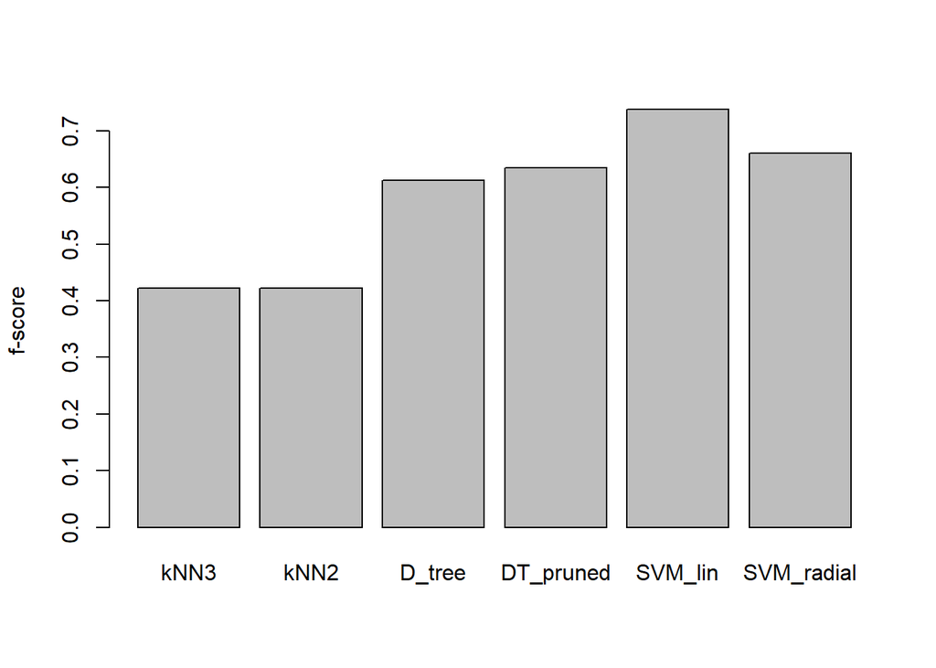

```r
fscore_vector=as.numeric(Table[2:7,4])
AUC_vector=as.numeric(Table[2:7,5])
barplot(fscore_vector,names.arg=c('kNN3','kNN2','D_tree','DT_pruned','SVM_lin','SVM_radial'), ylab='f-score')
```

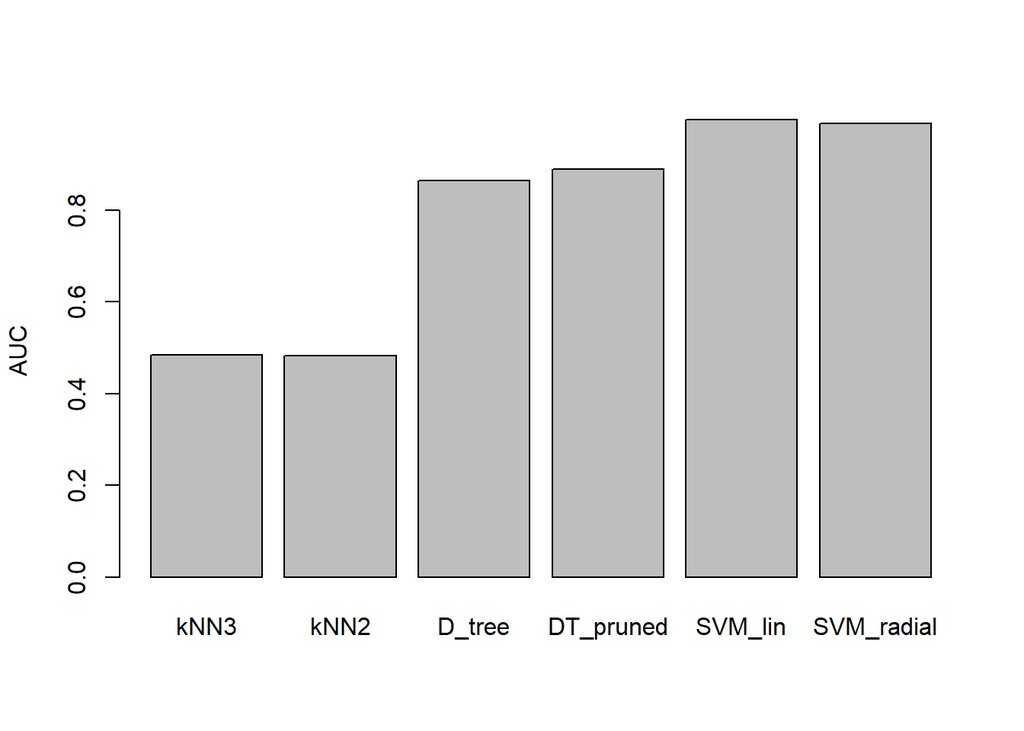

```r
barplot(AUC_vector,names.arg=c('kNN3','kNN2','D_tree','DT_pruned','SVM_lin','SVM_radial'), ylab='AUC')
```

#### Q3

```r
do.classification <- function(train.set, test.set,
                              cl.name, verbose=F) {
  ## note: to plot ROC later, we want the raw probabilities,
  ## not binary decisions
  switch(cl.name,
         knn = { # here we test k=3; you should evaluate different k's
           prob = knn(train.set[,-1], test.set[,-1], cl=train.set[,1], k = 3, prob=T)
           prob = attr(prob,"prob")
           #print(cbind(prob,as.character(test.set$y)))
           prob
         },
         lr = { # logistic regression
           model = glm(y~., family=binomial, data=train.set)
           if (verbose) {
             print(summary(model))
           }
           prob = predict(model, newdata=test.set, type="response")
           #print(cbind(prob,as.character(test.set$y)))
           prob
         },
         nb = {
           model = naiveBayes(y~., data=train.set)
           prob = predict(model, newdata=test.set, type="raw")
           #print(cbind(prob,as.character(test.set$y)))
           prob = prob[,2]/rowSums(prob) # renormalize the prob.
           prob
         },

         svm = {
           model = svm(y~., data=train.set,type="C-classification",kernel="linear", probability=TRUE)

           prob = predict(model, newdata=test.set,probability=TRUE)

           prob=attr(prob,"probabilities")

           prob = prob[,which(colnames(prob)==1)]/rowSums(prob)
           prob
         },
         ada = {
           model = ada(y~., data = train.set)
           prob = predict(model, newdata=test.set, type='probs')
           #print(cbind(prob,as.character(test.set$y)))
           prob = prob[,2]/rowSums(prob)
           prob
         }
  )
}

k.fold.cv <- function(dataset, cl.name, k.fold=10, prob.cutoff=0.5) {
  ## default: 10-fold CV, cut-off 0.5
  n.obs <- nrow(dataset) # no. of observations
  s = sample(n.obs)
  errors = dim(k.fold)
  probs = NULL
  actuals = NULL
  for (k in 1:k.fold) {
    test.idx = which(s %% k.fold == (k-1) ) # use modular operator
    train.set = dataset[-test.idx,]
    test.set = dataset[test.idx,]
    cat(k.fold,'-fold CV run',k,cl.name,':',
        '#training:',nrow(train.set),
        '#testing',nrow(test.set),'\n')
    prob = do.classification(train.set, test.set, cl.name)
    predicted = as.numeric(prob > prob.cutoff)
    actual = test.set$y
    confusion.matrix = table(actual,factor(predicted,levels=c(0,1)))
    confusion.matrix
    error = (confusion.matrix[1,2]+confusion.matrix[2,1]) / nrow(test.set)
    errors[k] = error
    cat('\t\terror=',error,'\n')
    probs = c(probs,prob)
    actuals = c(actuals,actual)
    ## you may compute other measures and store them in arrays
  }
  avg.error = mean(errors)
  cat(k.fold,'-fold CV results:','avg error=',avg.error,'\n')

  ## plot ROC
  result = data.frame(probs,actuals)
  pred = prediction(result$probs,result$actuals)
  perf = performance(pred, "tpr","fpr")
  return(perf)
}

dataset = load.data.example()
knn3_ROC = my.classifier(dataset, cl.name='knn',do.cv=T)
```

```
## my dataset: 800 observations 46 predictors
## pre-test knn : #training: 480 #testing 320
## error rate: 0.734375
## 10 -fold CV run 1 knn : #training: 720 #testing 80
##      error= 0.6375
## 10 -fold CV run 2 knn : #training: 720 #testing 80
##      error= 0.725
## 10 -fold CV run 3 knn : #training: 720 #testing 80
##      error= 0.725
## 10 -fold CV run 4 knn : #training: 720 #testing 80
##      error= 0.75
## 10 -fold CV run 5 knn : #training: 720 #testing 80
##      error= 0.75
## 10 -fold CV run 6 knn : #training: 720 #testing 80
##      error= 0.7875
## 10 -fold CV run 7 knn : #training: 720 #testing 80
##      error= 0.725
## 10 -fold CV run 8 knn : #training: 720 #testing 80
##      error= 0.65
## 10 -fold CV run 9 knn : #training: 720 #testing 80
##      error= 0.6625
## 10 -fold CV run 10 knn : #training: 720 #testing 80
##      error= 0.7875
## 10 -fold CV results: avg error= 0.72
```

```r
nb_ROC = my.classifier(dataset, cl.name='nb',do.cv=T)
```

```
## my dataset: 800 observations 46 predictors
## pre-test nb : #training: 480 #testing 320
## error rate: 0.1875
## 10 -fold CV run 1 nb : #training: 720 #testing 80
##      error= 0.1125
## 10 -fold CV run 2 nb : #training: 720 #testing 80
##      error= 0.175
## 10 -fold CV run 3 nb : #training: 720 #testing 80
##      error= 0.15
## 10 -fold CV run 4 nb : #training: 720 #testing 80
##      error= 0.225
## 10 -fold CV run 5 nb : #training: 720 #testing 80
##      error= 0.15
## 10 -fold CV run 6 nb : #training: 720 #testing 80
##      error= 0.1875
## 10 -fold CV run 7 nb : #training: 720 #testing 80
##      error= 0.2625
## 10 -fold CV run 8 nb : #training: 720 #testing 80
##      error= 0.15
## 10 -fold CV run 9 nb : #training: 720 #testing 80
##      error= 0.275
## 10 -fold CV run 10 nb : #training: 720 #testing 80
##      error= 0.225
## 10 -fold CV results: avg error= 0.19125
```

```r
lr_ROC = my.classifier(dataset, cl.name='lr',do.cv=T)
```

```
## my dataset: 800 observations 46 predictors
## pre-test lr : #training: 480 #testing 320
## error rate: 0.05
## 10 -fold CV run 1 lr : #training: 720 #testing 80
##      error= 0.0375
## 10 -fold CV run 2 lr : #training: 720 #testing 80
##      error= 0.0375
## 10 -fold CV run 3 lr : #training: 720 #testing 80
##      error= 0.025
## 10 -fold CV run 4 lr : #training: 720 #testing 80
##      error= 0.0375
## 10 -fold CV run 5 lr : #training: 720 #testing 80
##      error= 0.025
## 10 -fold CV run 6 lr : #training: 720 #testing 80
##      error= 0.025
## 10 -fold CV run 7 lr : #training: 720 #testing 80
##      error= 0.0125
## 10 -fold CV run 8 lr : #training: 720 #testing 80
##      error= 0.0625
## 10 -fold CV run 9 lr : #training: 720 #testing 80
##      error= 0.0125
## 10 -fold CV run 10 lr : #training: 720 #testing 80
##      error= 0.025
## 10 -fold CV results: avg error= 0.03
```

```r
svm_Lin_ROC = my.classifier(dataset, cl.name='svm',do.cv=T)
```

```
## my dataset: 800 observations 46 predictors
## pre-test svm : #training: 480 #testing 320
## error rate: 0.046875
## 10 -fold CV run 1 svm : #training: 720 #testing 80
##      error= 0.025
## 10 -fold CV run 2 svm : #training: 720 #testing 80
##      error= 0.025
## 10 -fold CV run 3 svm : #training: 720 #testing 80
##      error= 0.0125
## 10 -fold CV run 4 svm : #training: 720 #testing 80
##      error= 0.0125
## 10 -fold CV run 5 svm : #training: 720 #testing 80
##      error= 0.05
## 10 -fold CV run 6 svm : #training: 720 #testing 80
##      error= 0
## 10 -fold CV run 7 svm : #training: 720 #testing 80
##      error= 0.025
## 10 -fold CV run 8 svm : #training: 720 #testing 80
##      error= 0.0125
## 10 -fold CV run 9 svm : #training: 720 #testing 80
##      error= 0.0375
## 10 -fold CV run 10 svm : #training: 720 #testing 80
##      error= 0.025
## 10 -fold CV results: avg error= 0.0225
```

```r
ada_ROC = my.classifier(dataset, cl.name='ada',do.cv=T)
```

```
## my dataset: 800 observations 46 predictors
## pre-test ada : #training: 480 #testing 320
## error rate: 0.06875
## 10 -fold CV run 1 ada : #training: 720 #testing 80
##      error= 0.1
## 10 -fold CV run 2 ada : #training: 720 #testing 80
##      error= 0.075
## 10 -fold CV run 3 ada : #training: 720 #testing 80
##      error= 0.1125
## 10 -fold CV run 4 ada : #training: 720 #testing 80
##      error= 0.075
## 10 -fold CV run 5 ada : #training: 720 #testing 80
##      error= 0.05
## 10 -fold CV run 6 ada : #training: 720 #testing 80
##      error= 0.0625
## 10 -fold CV run 7 ada : #training: 720 #testing 80
##      error= 0.0625
## 10 -fold CV run 8 ada : #training: 720 #testing 80
##      error= 0.075
## 10 -fold CV run 9 ada : #training: 720 #testing 80
##      error= 0.075
## 10 -fold CV run 10 ada : #training: 720 #testing 80
##      error= 0.025
## 10 -fold CV results: avg error= 0.07125
```

```r
do.classification <- function(train.set, test.set,
                              cl.name, verbose=F) {
  ## note: to plot ROC later, we want the raw probabilities,
  ## not binary decisions
  switch(cl.name,


         dtree = {
           model = rpart(y~., data=train.set, method="class")
           if (verbose) {
             print(summary(model)) # detailed summary of splits
             printcp(model) # print the cross-validation results
             plotcp(model) # visualize the cross-validation results
             ## plot the tree
             plot(model, uniform=TRUE, main="Classification Tree")
             text(model, use.n=TRUE, all=TRUE, cex=.8)
           }

           if (1) { # here we use the default tree,
             ## you should evaluate different size of tree
             ## prune the tree
             pfit<- prune(model, cp=model$cptable[which.min(model$cptable[,"xerror"]),"CP"])
             prob = predict(pfit, newdata=test.set, type="prob")
             ## plot the pruned tree

           }

           print(dim(prob))
           #print(cbind(prob,as.character(test.set$y)))
           prob = prob[,2]/rowSums(prob) # renormalize the prob.
           prob
         }

  )
}

dtree_ROC = my.classifier(dataset, cl.name='dtree',do.cv=T)
```

```
## my dataset: 800 observations 46 predictors
## pre-test dtree : #training: 480 #testing 320
## [1] 320   2
## error rate: 0.16875
## 10 -fold CV run 1 dtree : #training: 720 #testing 80
## [1] 80  2
##      error= 0.1375
## 10 -fold CV run 2 dtree : #training: 720 #testing 80
## [1] 80  2
##      error= 0.1375
## 10 -fold CV run 3 dtree : #training: 720 #testing 80
## [1] 80  2
##      error= 0.1
## 10 -fold CV run 4 dtree : #training: 720 #testing 80
## [1] 80  2
##      error= 0.0875
## 10 -fold CV run 5 dtree : #training: 720 #testing 80
## [1] 80  2
##      error= 0.15
## 10 -fold CV run 6 dtree : #training: 720 #testing 80
## [1] 80  2
##      error= 0.175
## 10 -fold CV run 7 dtree : #training: 720 #testing 80
## [1] 80  2
##      error= 0.1625
## 10 -fold CV run 8 dtree : #training: 720 #testing 80
## [1] 80  2
##      error= 0.175
## 10 -fold CV run 9 dtree : #training: 720 #testing 80
## [1] 80  2
##      error= 0.225
## 10 -fold CV run 10 dtree : #training: 720 #testing 80
## [1] 80  2
##      error= 0.2125
## 10 -fold CV results: avg error= 0.15625
```

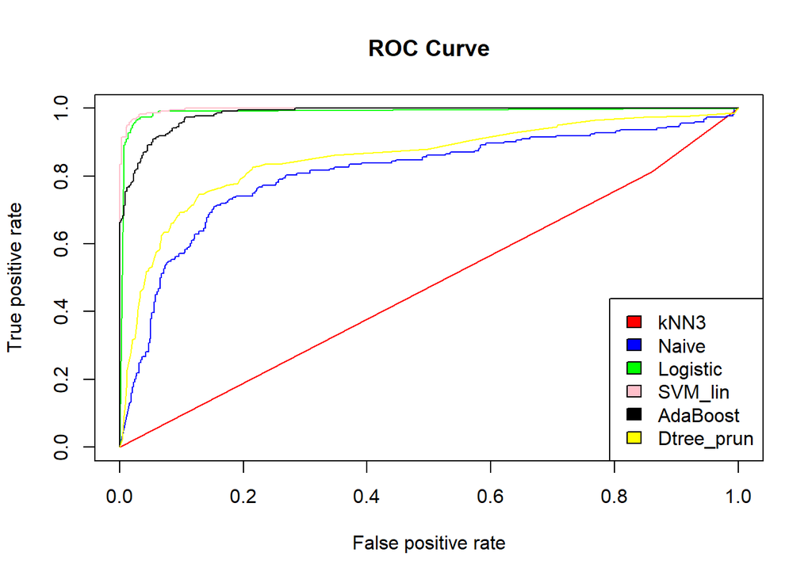

```r
plot(knn3_ROC,main="ROC Curve", labels="kNN3", col="red")
plot(nb_ROC, add=TRUE, labels="Naive",col="blue")
plot(lr_ROC, add=TRUE, col="green")
plot(svm_Lin_ROC, add=TRUE, col="pink")
plot(ada_ROC, add=TRUE, col="black")
plot(dtree_ROC, add=TRUE, col="yellow")

legend("bottomright",
c("kNN3","Naive","Logistic","SVM_lin","AdaBoost","Dtree_prun"),
fill=c("red","blue","green","pink","black","yellow")
)
```

#### Q4

Overall, the models which performed really well are SVM, Adaboost, logistic regression. Among these, the f-score of logistic regression was drastically higher than others.The performances of the models, Naive Bayes and Decision Tree were relatively good but not better than the models mentioned above. This could be because in Naive Bayes we assume that features are independent of each other, which may not be always true. The worst performance was shown by kNN. I didn’t try increasing the k value above 3, kNN performance could improve with increasing k.

The performance ranking of the models according to their AUC are: 1)SVM-linear 2)Logistic regression 3)Adaboost 4)Pruned decision tree 5)Naive Bayes 6)k-Nearest Neighbours(k=3)